# Governing the Future’s Power System

Use arrow keys of finger slide left to navigate.  
Some slides have notes -  
press 'p' key or a button on a slide to trigger them.

September 2, 2015

## The Context

## Transition

- The existing market concept is based on large-scale, centralized power plants, supplying individual and business consumers with as much electricity as they want; users are passive (and perceived as such);
- The move towards decentralised generation increases the number of involved players and wipes away existing market roles; the clear hierarchical structure of the existing power grid is being disrupted;
- The single most important question:  
  **How to transform the European power system from a traditional, fragmented grid into a continent-wide smart grid?**
- The answer is:  
  **Nobody knows…**

## The Current Situation: centralized power generation

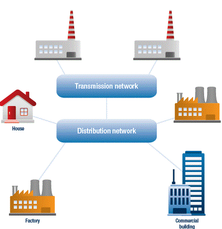

## The Future Vision: distributed power generation

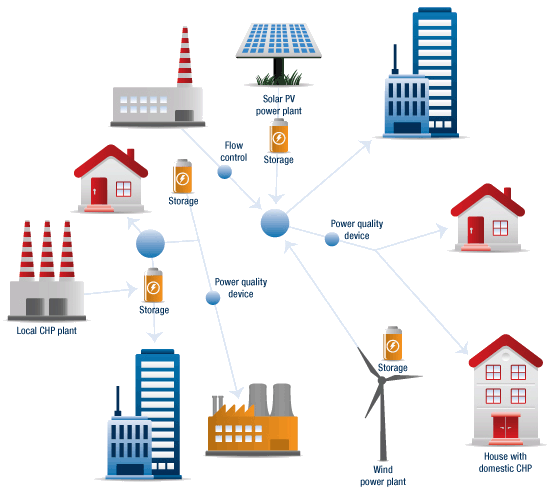

## Issues

- Markets are not sufficiently flexible, neither on the supply nor the demand side;
- Market mechanisms are not working - price signals are still distorted; it is unclear how much liberalization is accepted; pricing mechanism is debated;
- Old governance models do not work, new governance models do not seem to exist;
- Current players are stuck with old models and are locked in conflicts of interest over new ones;
- Bottom line, the current approach is predominantly "technical" (except the high level strategy):
  - More interconnections;
  - More smart meters;
  - More data / analysis / models;
  - Definition of new roles for TSO's and DSOs…
- While the strategic direction is "clear", stakeholders have opposite views on the paths to be taken..

## The different mindset: Complex Systems thinking

## 1: Complex Adaptive Systems

- The Future Smart Grid is a [**Complex Adaptive System**](https://en.wikipedia.org/wiki/Complex_adaptive_system) and should be approached as such:
  - it cannot function in a centralized command-and-control (i.e. top-down) manner;
  - it is a network of interacting agents, constantly changing their contributions and demands in relation to their diverse **local** contexts;
  - interdependencies among the agents involve transfers of energy (power grid), money (market), information (Internet), coordination and more;
- **Implication:** such system does not lend itself to analysis based on traditional structures and thinking - i.e. TSOs, DSOs, interactions among them and the question how can they control the system;

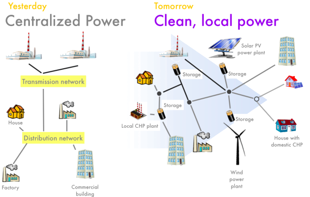

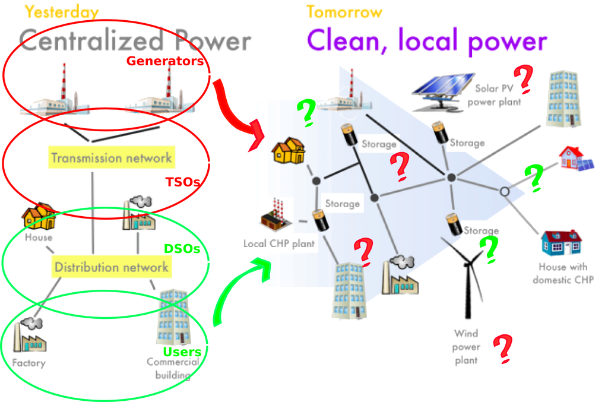

## 2: Dynamic network of heterogeneous agents

- The Future Smart Grid is a network of semi-independent heterogeneous agents:
  - power plants, power lines, individual customers; individual smart appliances, storages, electric cars, companies, etc.;
  - agents are subsystems that can undertake autonomous actions to achieve their **individual goals**;
  - furthermore, some agents (microgrids, service providers, institutions, etc.) are themselves complex adaptive systems which makes the overall system a **hyper-complex one**;

## Distributed Governance

## Guided Self-Organization

- The management of a complex adaptive system as a dynamic network of heterogeneous agents cannot be achieved any more by central planning and control;
  - *Theoretically*: due to non-linear interrelationships among diverse agents an unexpected small event can have large effects on the system;
  - *Practically*: in order for the system to operate efficiently, every agent will have to make autonomous decisions based on its own local context and goals;
  - Centralization would make the system more rigid, but **not more secure/resilient**.
- Instead, what is needed is a strategy of **guided self-organization**: defining the broad 'rules of play' which encourage bottom-up initiatives and actions of independent agents;
- An important principle of guided self-organization is the emphasis on the resilience of the system rather than on attempts to determine precise paths of development towards a long term goal or a specific desired configuration.

## Guiding a process vs. managing a system

- Traditional understanding of system's management:
  - assumes a *stable* system,
  - sees market players with clearly defined roles and responsibilities;
  - proposes a hierarchy of control, encoded in network codes, ensuring the stability and safety of the system;
- In the future Smart Grid, this will not be possible:
  - the system will be fluid - the very idea of a Smart Grid is to create an adaptive system capable of dynamic power supply and demand matching in the regime of distributed generation;
  - the roles and boundaries of traditional market players are already blurring and will continue to become more so; they will be determined dynamically depending on the local context;
  - new players with innovative roles will constantly emerge and/or disappear;
- Managing the system will become more a matter of **guiding the process of change** than understanding and controlling a 'stable' system.

## Security and resilience

- The crucial aspect of power grid is its security in terms of ensuring uninterruptable power supply and preventing blackouts / islanding;
- In the distributed system this is a challenge which cannot be achieved by the top-down control; yet reliance only on market forces and bottom-up incentives does not provide the required level of security either;
- The challenge of the Smart Grid governance is to find a balance between top-down and bottom-up forces and initiatives best ensuring the system's overall resilience;
- There is no ready recipe for this; but Complex Systems Science inform us well about the direction of inquiry in a systematic way;
- GBI offers their expertise in designing a model of **Distributed Governance** based on principles of self-organization and complex systems science as presented above;

## Data management and IT systems

## Current situation

- The design issues of the IT system for the Smart Grid (which can be understood as the Smart Grid itself) are approached from the trenches of traditional market players;
- Often therefore, the debate about IT systems design is being reduced to questions:
  - which entities (DSOs or TSOs) are going to "own" which data, i.e. fragmenting the market by building artificial barriers between participants;
  - how data is going to be interchanged among the players;
  - also, there are attempts to 'monopolize' the collection, control and usage of data and in this way secure certain market niches;
- Not surprisingly, data management issues create another deadlock among market participants which try to delineate their zones of influence in the new system;

## General suggestions

- IT systems' (as well as the whole network's) 'design' cannot be approached from the positions of current market participants, because:
  - they will most probably not exist in the future system;
  - it leads to artificial fragmentation of the market;
- The architecture should be based on the approach to the sought European power system as a dynamic network of heterogeneous agents (microgrids, prosumers, smart appliances, small producers, different combinations of these);
- The IT systems should be adaptable enough to be able to accommodate the needs of these new players; many of which cannot be known in advance;
- The design of IT systems' for the Smart Grid should emphasize the development of open protocols and standards (such as [Open Smart Grid Protocol](http://www.osgp.org/what-is-osgp/)) which enable agents of the network to communicate efficiently - much like the development of the Internet and mobile telecommunication standards.

## Specific suggestions

- It is obvious that IT systems for the distributed smart grid should be distributed as well, i.e. they should be designed on the basis of the [Distributed Computing] paradigm;
- The most important properties of a distributed (computing) system are:
  - the system is composed of a number of heterogeneous and more or less loosely connected components / processes;
  - any component of the system can have only **partial knowledge** of the whole system;
  - the global behaviour of the system can be affected only by influencing local behaviours and interactions of the components (e.g. via system wide rules or, in extreme cases, local interventions);
- Two technological paradigms which fit this description are:
  - **Agent-base modelling** (for modelling and simulation of the Smart Grid);
  - **Event based Service Oriented Architecture** (for enabling the interaction of heterogeneous agents in a network);

## Workshop

## Distributed governance of the Smart Grid

## Designing governance principles

- In terms of process management, at the abstract enough level, the transition from current power grid to the Smart Grid and the governance of Smart Grid are similar tasks - both are concerned with the **change management**;
- Therefore, the new model of the distributed governance, which is the main subject of the research programme, would serve both for the transition and future governance of the system (which will be ever changing and evolving);
- As mentioned earlier, guided self-organization of the complex system involves balancing
  - top-down policies in terms of 'rules of play' and
  - bottom-up incentives of market players (heterogeneous agents) based on their local context.

## Rules of play

- The overall goal of the regulators in balancing top-down rules with the bottom-up initiatives are twofold, both of which can be defined and operationalized at systemic level:
  - Resilience and security of the system;
  - Efficiency of energy markets;
- The rules of play, or the general principles of Smart Grid operation will be proposed by operationalizing the conceptual frameworks of complex adaptive systems and dynamic networks of heterogeneous agents as it applies to the power grid;
- In order to model the overall system's behaviour, we have to determine how 'rules of play' will interact with the interests and incentives of the market players;
- The rules of play themselves should be general enough to allow for local differences, which are unavoidable and even desirable, taken into account the technical and cultural differences among member states and the flexibility needed to allow self-organization dynamics of the market;

## Bottom up incentives

- Identifying and analysing bottom-up incentives is different for current and future stakeholders.
- For the existing stakeholders, the procedure is quite straightforward:
  - it may be enough to perform the Qualitative Data Analysis on the existing position and consultation documents;
  - in case it is not enough, deep structured interviews with selected market participants may be performed according to the [Public Policy Design methodology](http://www.erc.lt/userfiles/about-public-policy-design-methodology.pdf);
- The disruptive process of transition introduces certain difficulties of identifying *future* stakeholders. Two principles may be employed for this task:
  - Breaking down the system to its smallest elements and treating them as independent agents, in this way identifying their 'interest' (see Future Vision and Dynamic Network);
  - Identifying and actively pursuing new market players regardless of their market power (e.g. for the modelling of the new system it may be more valuable to know interests of a few emerging microgrids than large and powerful DSOs);

## Stakeholders' management for guided self-organization

- A central aspect of the governance process is a systemic stakeholders' management, which consists of:
  - identifying **all** stakeholders;
  - identifying their needs, interests and projections;
  - analysing the market structure by conceptual modelling the interaction of stakeholders' among themselves;
  - analyse how the existing 'rules of play' influence the individual incentives and behaviours;
  - considering the future vision of the system (in this case - the Smart Grid), design the policy interventions for guiding (but not controlling) the system's development;
  - organize periodic consultations / discussions regarding rules of play and designed policy interventions with the representatives of all stakeholders.
- Stakeholders' management is a continuous process; The Distributed Governance of the future Smart Grid encompasses it as briefly explained above;

## Modelling and simulation

- The results of conceptual modelling of the specific broad policies (rules of play), policy interventions and specific behaviours of market participants should be further checked by means of computer modelling / simulation;
- As explained above, the appropriate modelling paradigm for the Smart Grid is agent-based modelling and SOA 2.0;
- Research programme would ideally include the development of the simulation of the Smart Grid as a complex adaptive system, based on the GBI's expertise and past research and Key Stakeholder's experience / data;
- The goal of the modelling are:
  - **not to predict** the exact trajectories of the development of the system or its 'optimal' configuration;
  - but **to ensure the resilience** and efficiency of the system subjected to unpredicted events;
  - as well as test the assumptions and insights of the conceptual modelling phase;

## Summary

- Guided self-organization is a continuous process for change management;
  - As such, this process does not amount only to planning the desired future state of the system and designing the trajectory of change from current state to the future state;
  - Rather, guided self-organization emphasizes the limited planning horizon of complex systems and the need for continuous guidance (navigation) of the process depending on the immediate context and local perturbations;
- Distributed governance is a process of guided self-organization of distributed systems - the ones where there is no one component which can determine the course of the system;
  - Therefore, no single interest group or stakeholder (including regulatory institutions) can enforce any value system or approach to other participants. Therefore stakeholder interaction dynamics is what determines the evolution of the complex system;
- Stakeholders' management for guided self-organization is the paradigm of integrating stakeholders' interests and guiding the dynamics of interactions;